# Data Analysis on NYC City Bikes Performance (2018)

Kahlen Cheung

21-04-2022

```r
knitr::opts_chunk$set(echo = TRUE, fig.align = "left")
knitr::opts_chunk$set(tidy = "styler")

library(tsibbledata)
library(tsibble)
library(tidyverse)
library(janitor)
library(lubridate)
```

## Overview

The **Data Analysis on NYC City Bikes Performance 2018** (the report)is based on the research on the usage of 10 bikes in 2018 by [NYC Citi Bike](https://citibikenyc.com/homepage) There are a total of 4268 observations, covering customers’ gender, age, gender, bike usage type, as well as trips details including start and end times and locations.

## Data Ethic Guidline

The data used in this report is a public source stored in the Github `tidyverse package`. There is not direct consent authorized by NYC Citi Bikes or NYC Citi Bikes’s users. This report is only used for data analysis case study.

On behalf of the data collected by NYC Citi Bikes, there is not evidence show that it disclosure users’ private data: such as names, personal ID, or address etc. However, the Citi Bike app and the online payment system record users’ travelling pattern and consumption habits，which may cause the risk to expose personal behaviors to the third party without agreement.

## Objective

This report explores the overall bike hiring service performance in 2018. The analysis focuses on the sectors of:

- The relations between gender and customer type;
- The relations between travel duration and age;
- Performance by month;
- Performance by weekday;
- An overview of popularity of different stations

## Report flow

- Data cleaning and wrangling
- Data analysis and visualizations
- Key Suggestions

#### Data cleaning and wrangling

The original size of the dataset were 12 variables with 4268 observations. For a better evaluation and understanding of the topic, it is expanded with 6 more columns: the separated columns for year, month, weekday and date, age and travelled duration. The table is saved as `nyc_bikes_mass`.

**View dataset**

```r
knitr::kable(nyc_bikes_mass[1:5, 1:17], format = "markdown")
```

| bike_id | start_time | date | month | year | stop_time | travelled_time | start_station | start_lat | start_long | end_station | end_lat | end_long | type | age | birth_year | gender |
| --- | --- | --- | --- | --- | --- | --- | --- | --- | --- | --- | --- | --- | --- | --- | --- | --- |
| 26301 | 2018-02-26 19:11:03 | 26 | February | 2018 | 2018-02-26 19:15:40 | 4.618300 mins | 3186 | 40.71959 | -74.04312 | 3203 | 40.72760 | -74.04425 | Subscriber | 32 | 1986 | Male |
| 26301 | 2018-02-27 07:52:49 | 27 | February | 2018 | 2018-02-27 07:58:13 | 5.398733 mins | 3203 | 40.72760 | -74.04425 | 3202 | 40.72722 | -74.03376 | Subscriber | 39 | 1979 | Male |
| 26301 | 2018-02-27 12:03:27 | 27 | February | 2018 | 2018-02-27 12:04:54 | 1.442117 mins | 3202 | 40.72722 | -74.03376 | 3638 | 40.72429 | -74.03548 | Subscriber | 55 | 1963 | Male |
| 26301 | 2018-02-27 13:53:51 | 27 | February | 2018 | 2018-02-27 14:21:04 | 27.215750 mins | 3638 | 40.72429 | -74.03548 | 3638 | 40.72429 | -74.03548 | Subscriber | 34 | 1984 | Male |
| 26301 | 2018-02-27 14:30:42 | 27 | February | 2018 | 2018-02-27 14:33:11 | 2.475567 mins | 3638 | 40.72429 | -74.03548 | 3187 | 40.72112 | -74.03805 | Subscriber | 38 | 1980 | Male |

Change the weekday column to a proper weekday format, and save the table as `nyc_bikes_mass_weekday`.

**View dataset**

```r
knitr::kable(nyc_bikes_mass_weekday[1:5, 1:18], format = "markdown")
```

| bike_id | start_time | date | month | year | weekday | stop_time | travelled_time | start_station | start_lat | start_long | end_station | end_lat | end_long | type | age | birth_year | gender |
| --- | --- | --- | --- | --- | --- | --- | --- | --- | --- | --- | --- | --- | --- | --- | --- | --- | --- |
| 26301 | 2018-02-26 19:11:03 | 26 | February | 2018 | Monday | 2018-02-26 19:15:40 | 4.618300 mins | 3186 | 40.71959 | -74.04312 | 3203 | 40.72760 | -74.04425 | Subscriber | 32 | 1986 | Male |
| 26301 | 2018-02-27 07:52:49 | 27 | February | 2018 | Tuesday | 2018-02-27 07:58:13 | 5.398733 mins | 3203 | 40.72760 | -74.04425 | 3202 | 40.72722 | -74.03376 | Subscriber | 39 | 1979 | Male |
| 26301 | 2018-02-27 12:03:27 | 27 | February | 2018 | Tuesday | 2018-02-27 12:04:54 | 1.442117 mins | 3202 | 40.72722 | -74.03376 | 3638 | 40.72429 | -74.03548 | Subscriber | 55 | 1963 | Male |
| 26301 | 2018-02-27 13:53:51 | 27 | February | 2018 | Tuesday | 2018-02-27 14:21:04 | 27.215750 mins | 3638 | 40.72429 | -74.03548 | 3638 | 40.72429 | -74.03548 | Subscriber | 34 | 1984 | Male |
| 26301 | 2018-02-27 14:30:42 | 27 | February | 2018 | Tuesday | 2018-02-27 14:33:11 | 2.475567 mins | 3638 | 40.72429 | -74.03548 | 3187 | 40.72112 | -74.03805 | Subscriber | 38 | 1980 | Male |

#### Data analysis and visualizations

In this section we will explore more about the dataset by visualizations

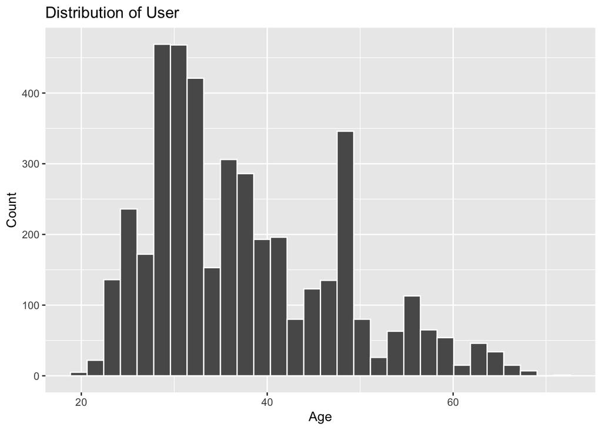

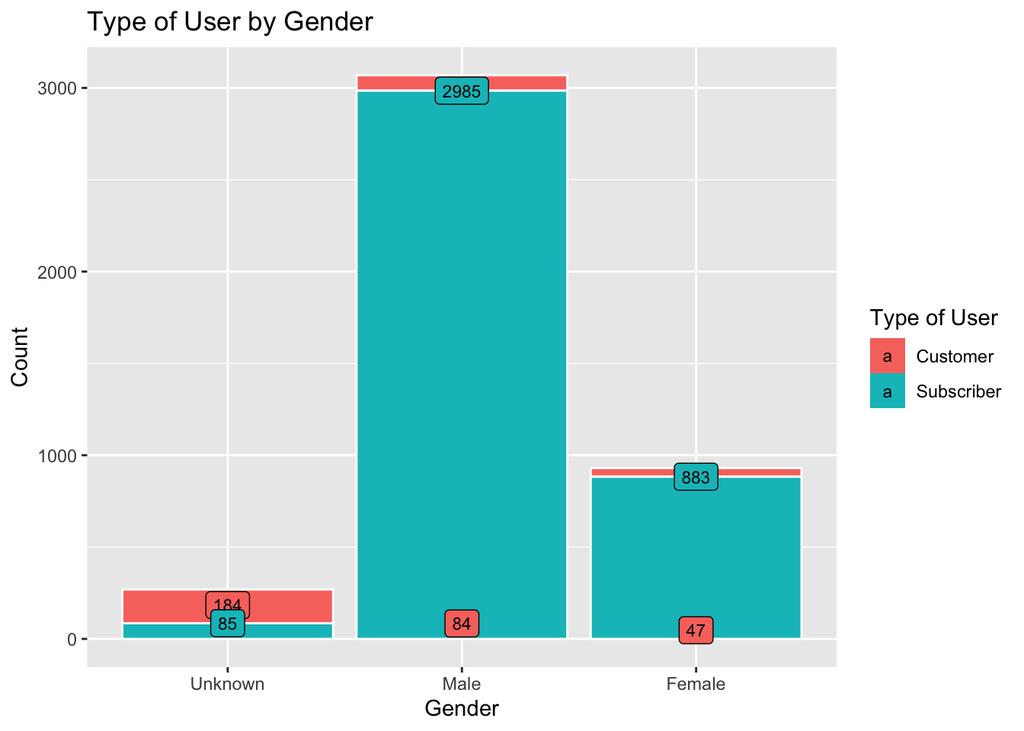

Suggestions  
*There is still room to expand female users, where an appropriate marketing plan for targeting female is required.*

2. *An analysis on gender and number of user by Month*
- This visualizations contains the observations of gender, number of user and usage of each month in 2018.
- The plot shows that in July and August, the bicycle hiring service has the highest volume of demand, while January and February has the least.
- The mean of number of user in each month is **355**, where 6 months (May to October) meet the value.

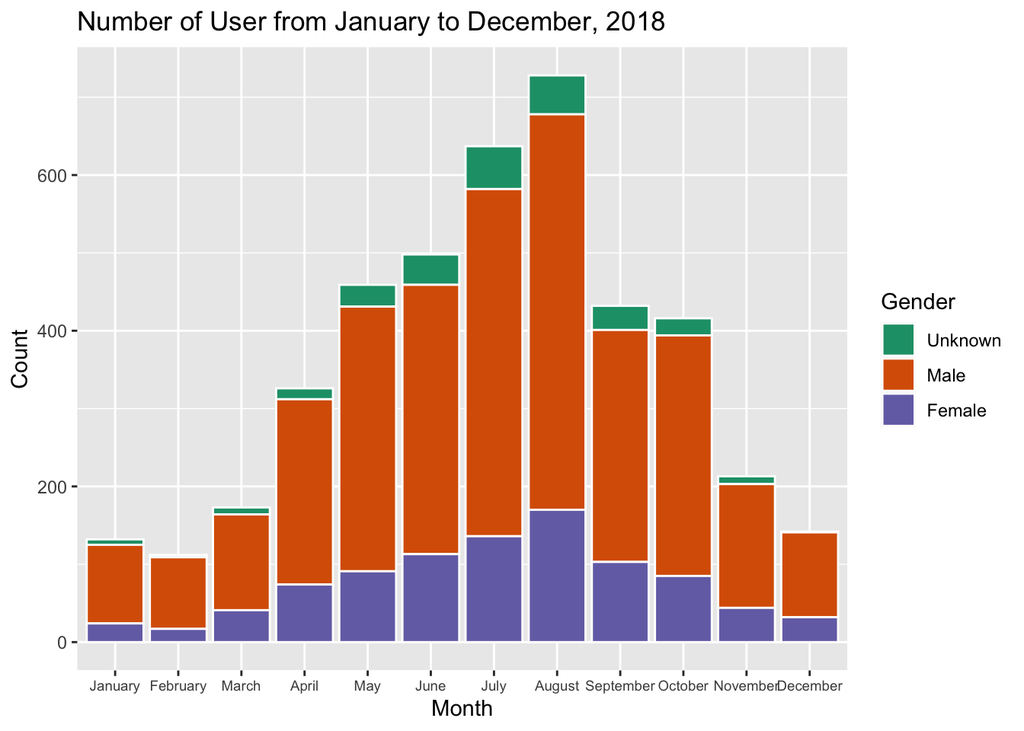

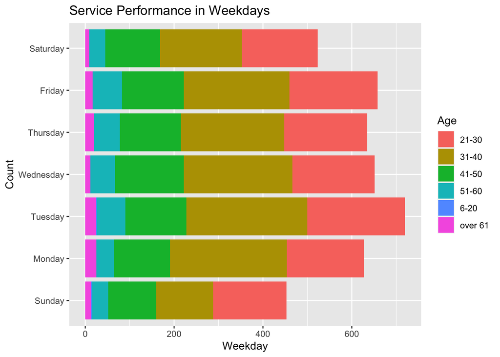

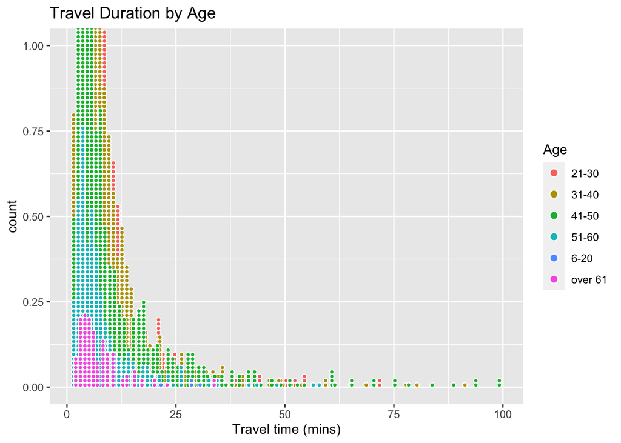

Suggestions  
*A promotion targeting to people age over 50 would help expand the age range of users. As well as a discount plan on Sunday, or riding time over 50 mins may attract more users.*

4. *An overview of popularity of different stations*
- This geographic interprets the locations of the 52 stations in New York City.
- The blue markers show the top 3 most popular stations: `Richmond Rd(3186)`, `Steinway St(3203)`, `Sip Ave(3195)`.
- The warning markers show the stations which people of count in usage is fewer than 20.
- Stations located in non city centre area have fewer users.

[interactive chart not shown]

Suggestions  
*Stations away from city centre may stress on the running cost in a long term.*

The End